# Permutation Statistics Analyses

## Small vs Large conditions

### Feedback-related Negativity (FRN)

This is time-locked to feedback onset. Analyses includes 10 fronto-central-parietal electrodes:

FCz, F3, Fz, F4, C3, Cz, C4, P3, Pz, P4

#### Comparison to aligned reaches (baseline)

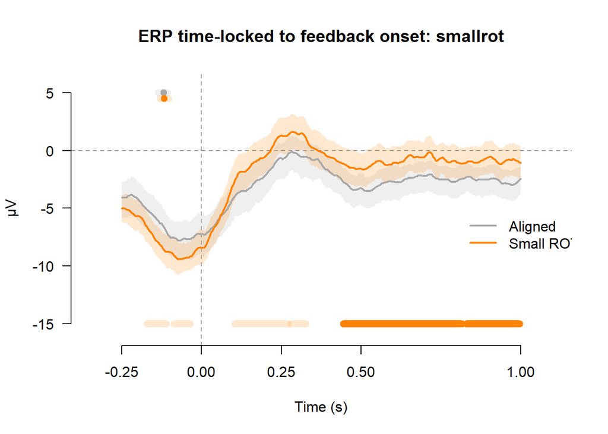

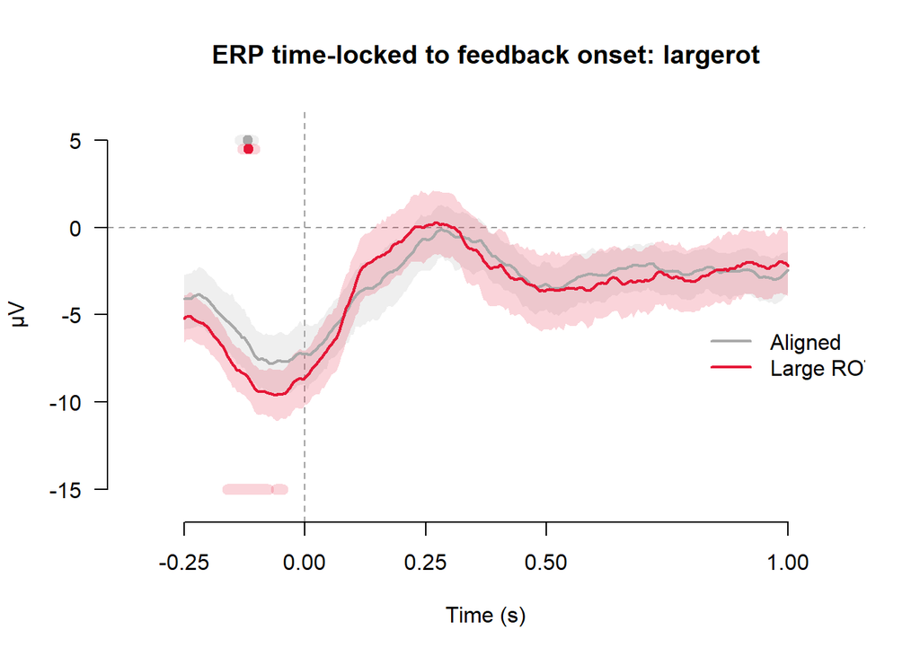

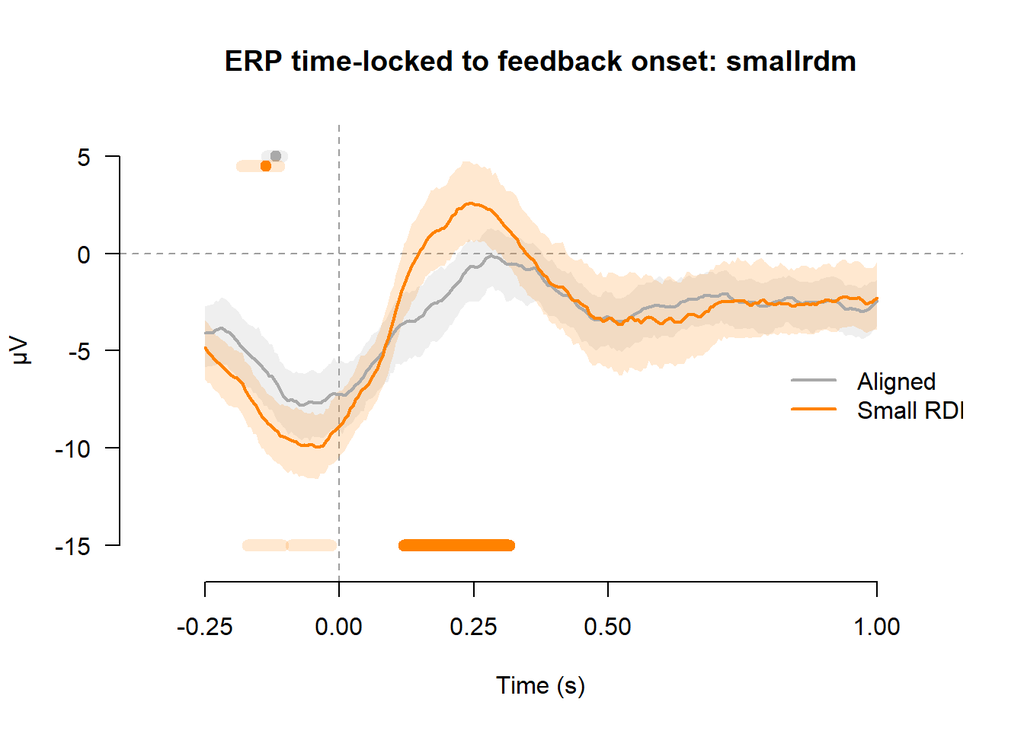

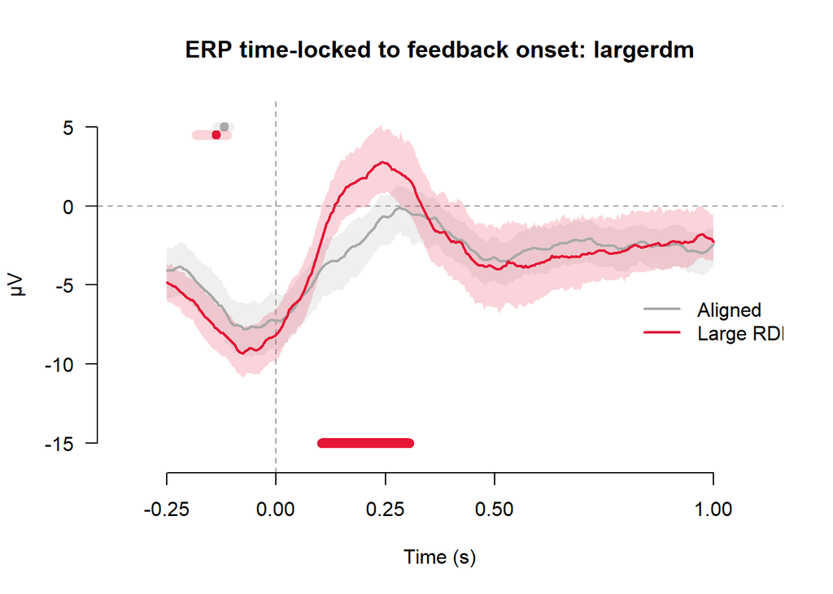

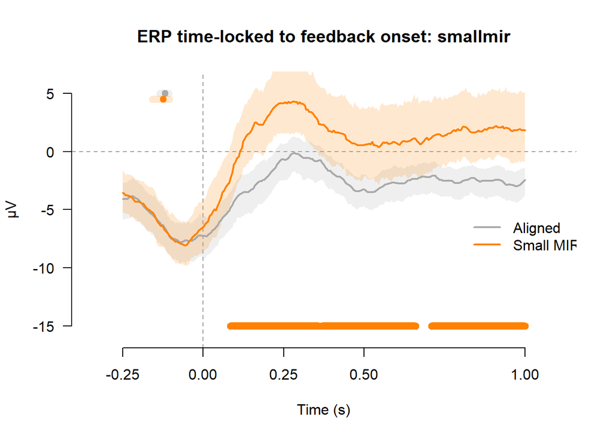

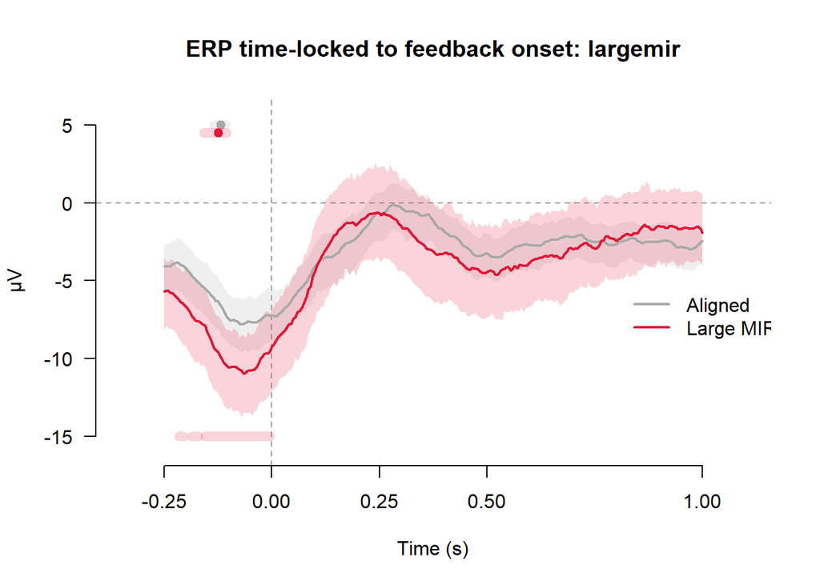

```r
plotPermTestSmallLargeERPs()
```

#### Comparison between early and late training

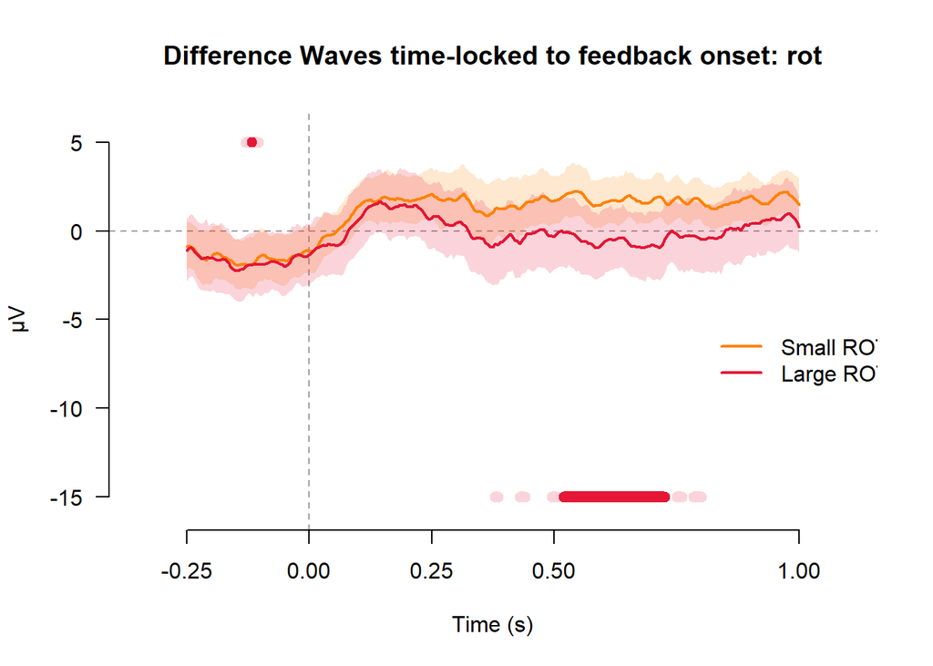

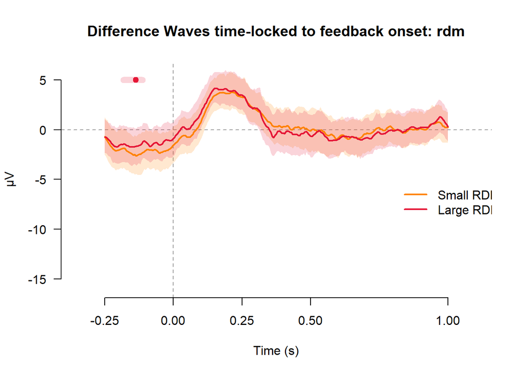

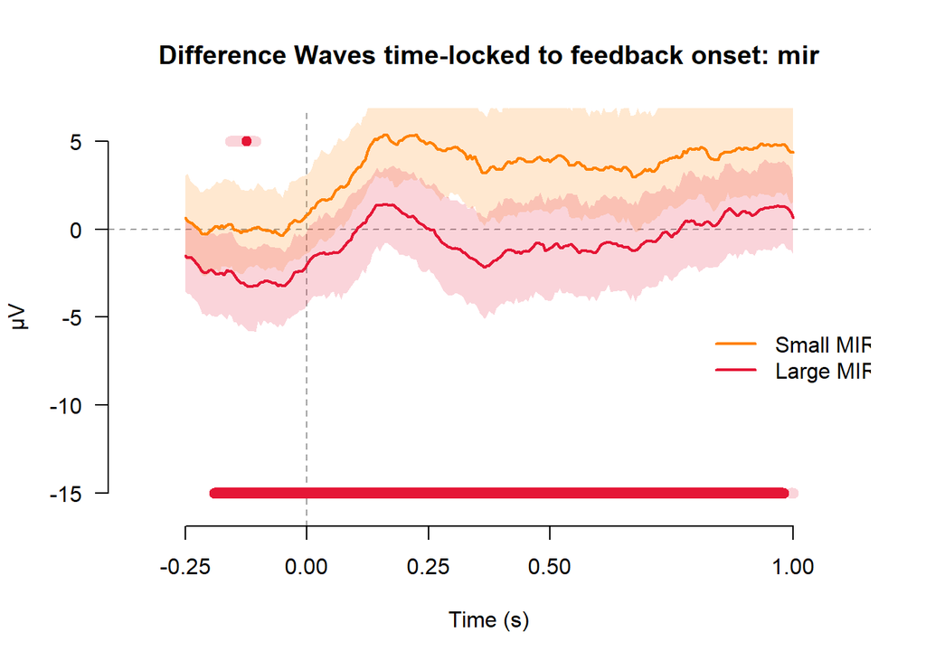

```r
plotPermTestSmallLargeDiffWaves()
```

#### Comparison across perturbation types

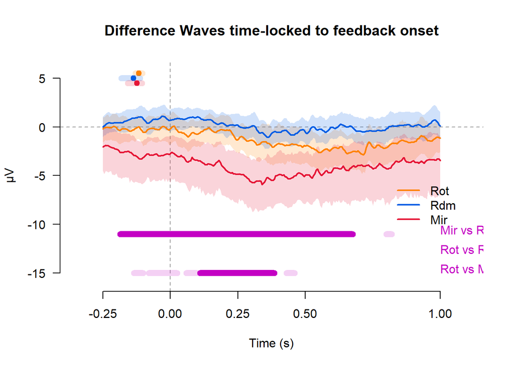

```r
plotPermTestPTypeSmallLargeDiffWaves()
```

### P3 component

This is also time-locked to feedback onset, but only considers electrodes along the midline:

FCz, Fz, Cz, Pz

#### Comparison to aligned reaches (baseline)

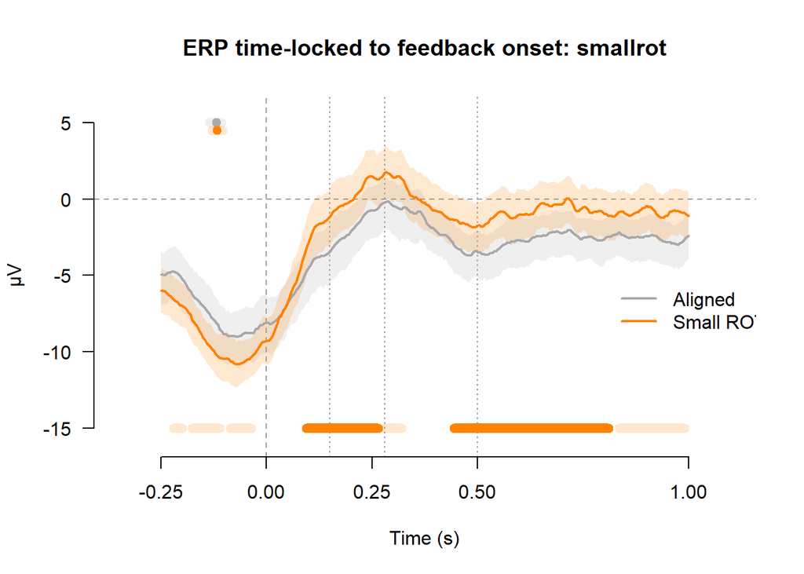

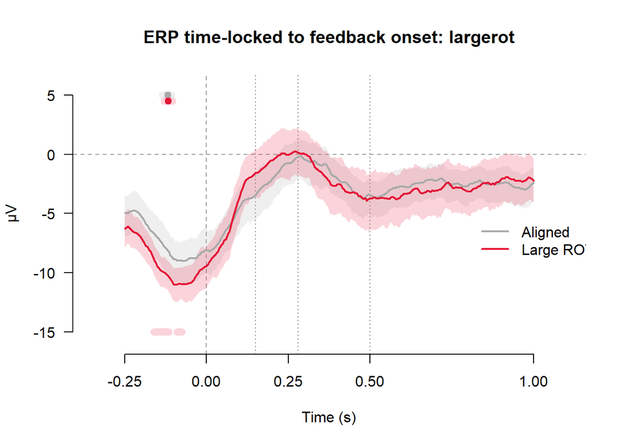

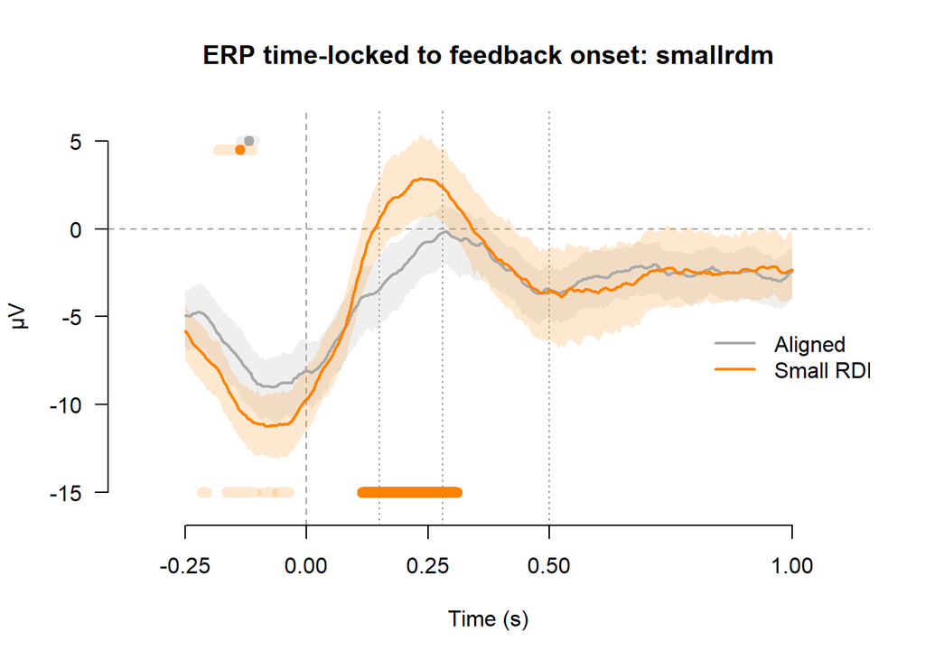

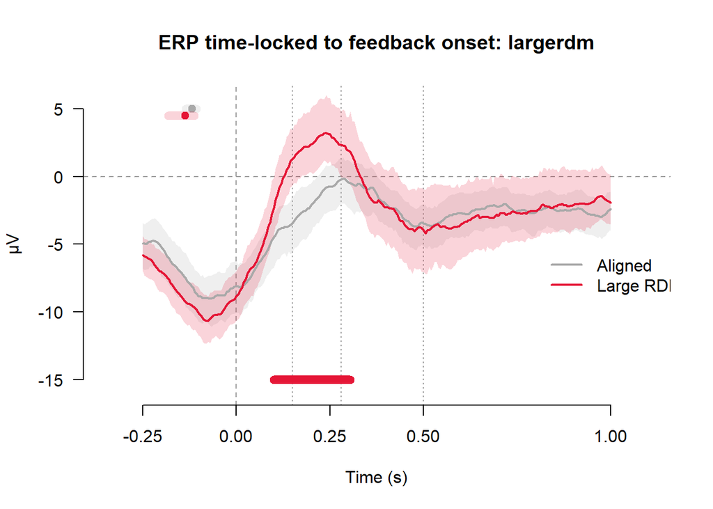

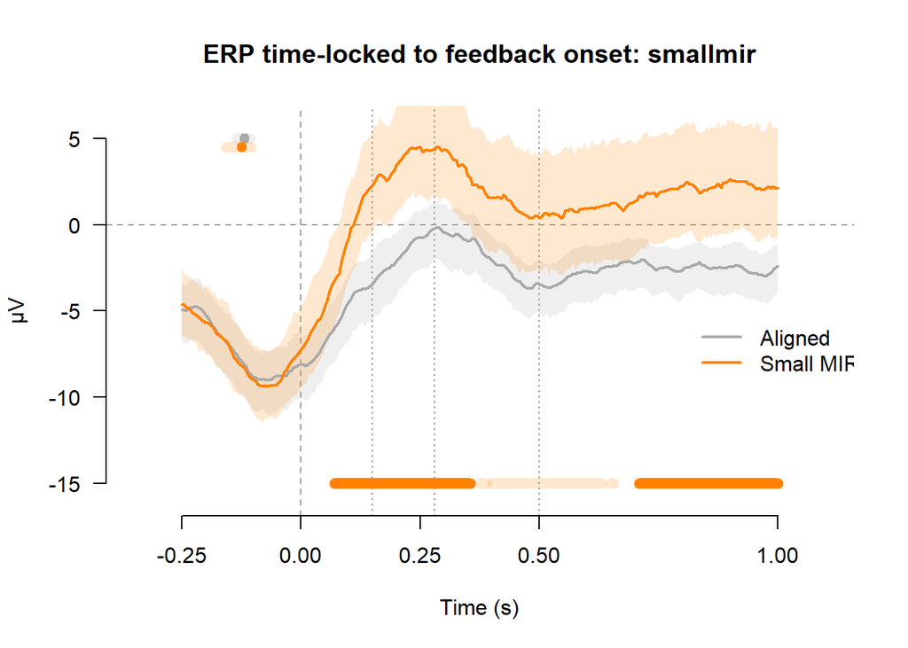

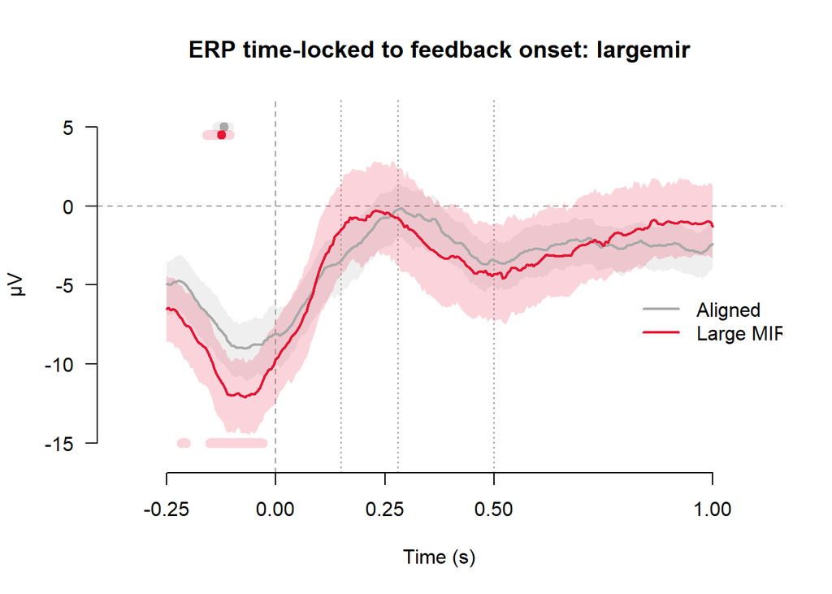

```r
plotPermTestSmallLargeP3()
```

#### Comparison between early and late training

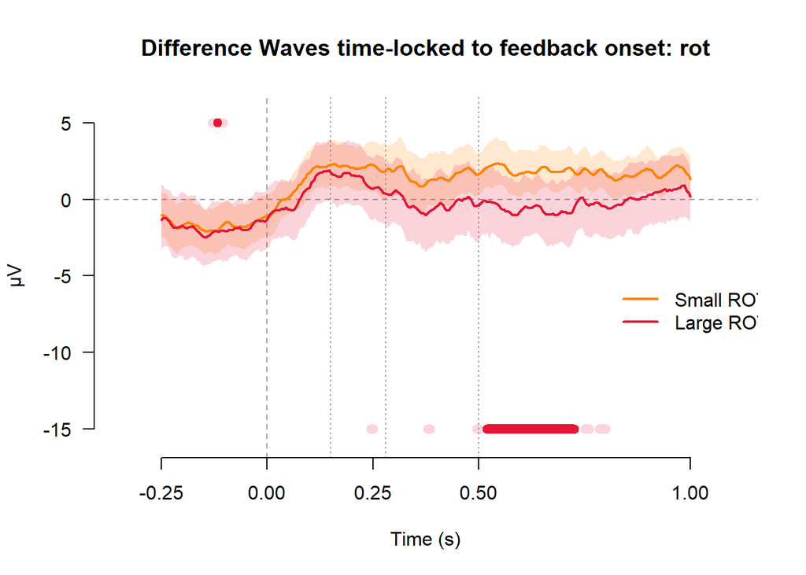

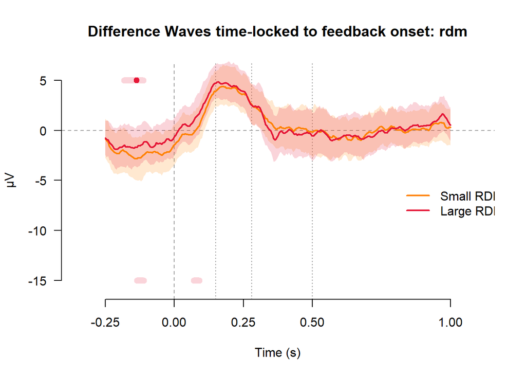

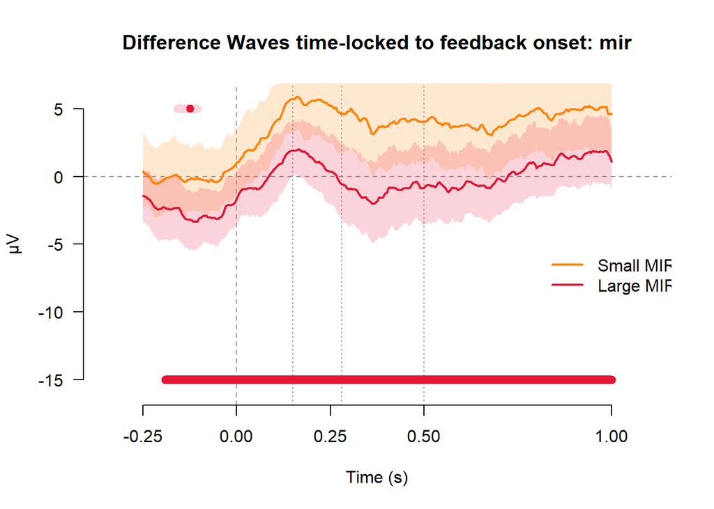

```r
plotPermTestSmallLargeDiffWavesP3()
```

#### Comparison across perturbation types

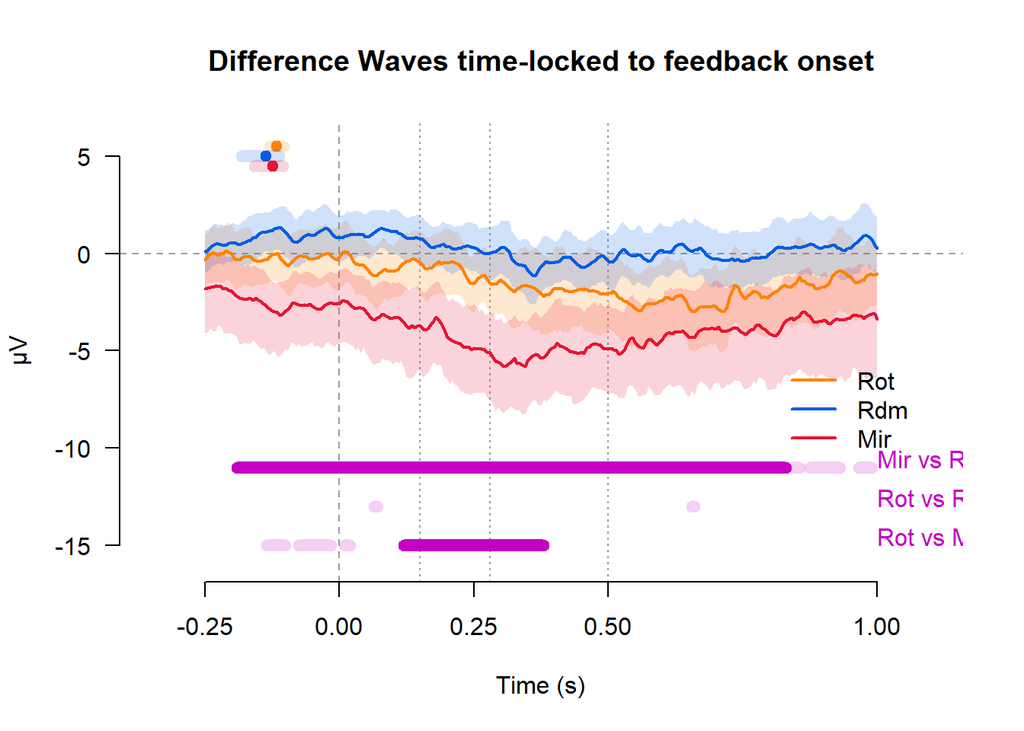

```r
plotPermTestPTypeSmallLargeDiffWavesP3()
```

### Lateralized Readiness Potential (LRP)

This is time-locked to the go signal onset, which is 1 second after target onset. Analyses includes C3 and C4 electrodes, and considers only reaches to the left or right side of the workspace.

#### Comparison to aligned reaches (baseline)

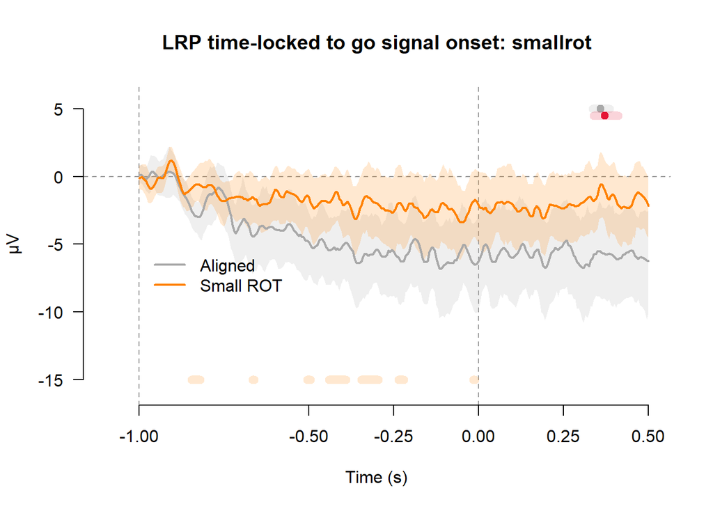

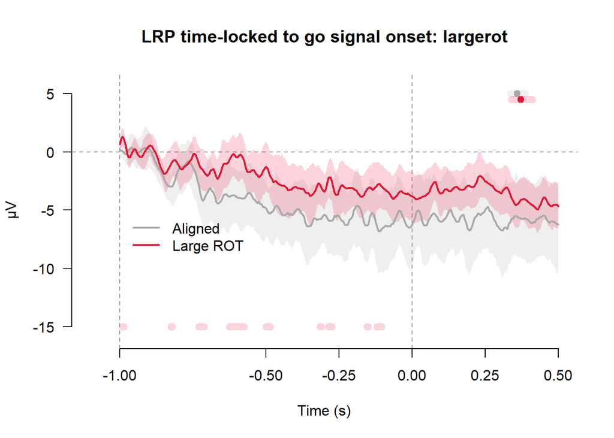

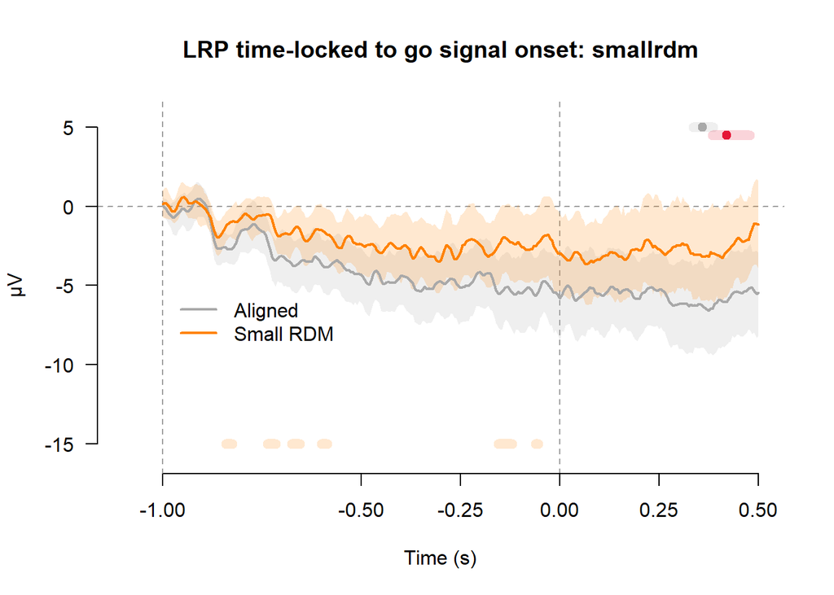

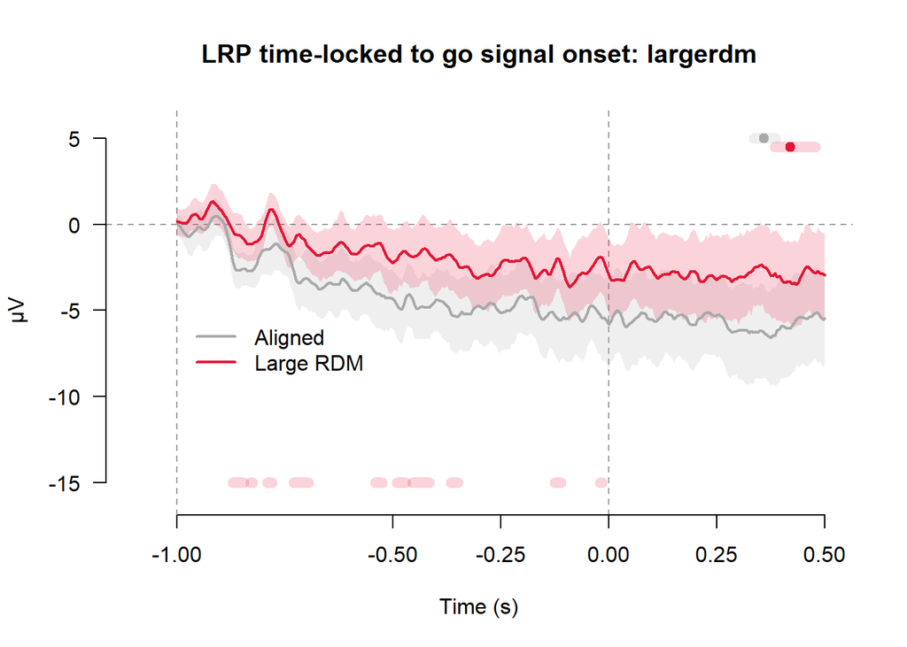

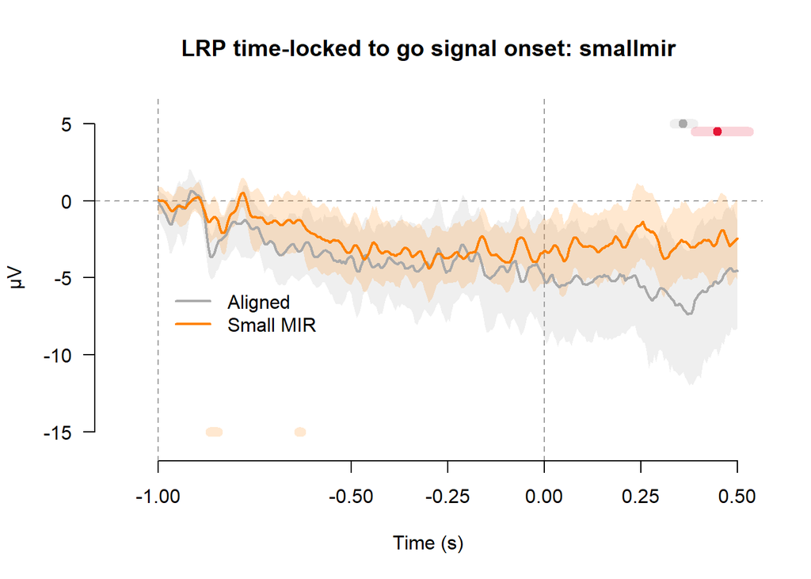

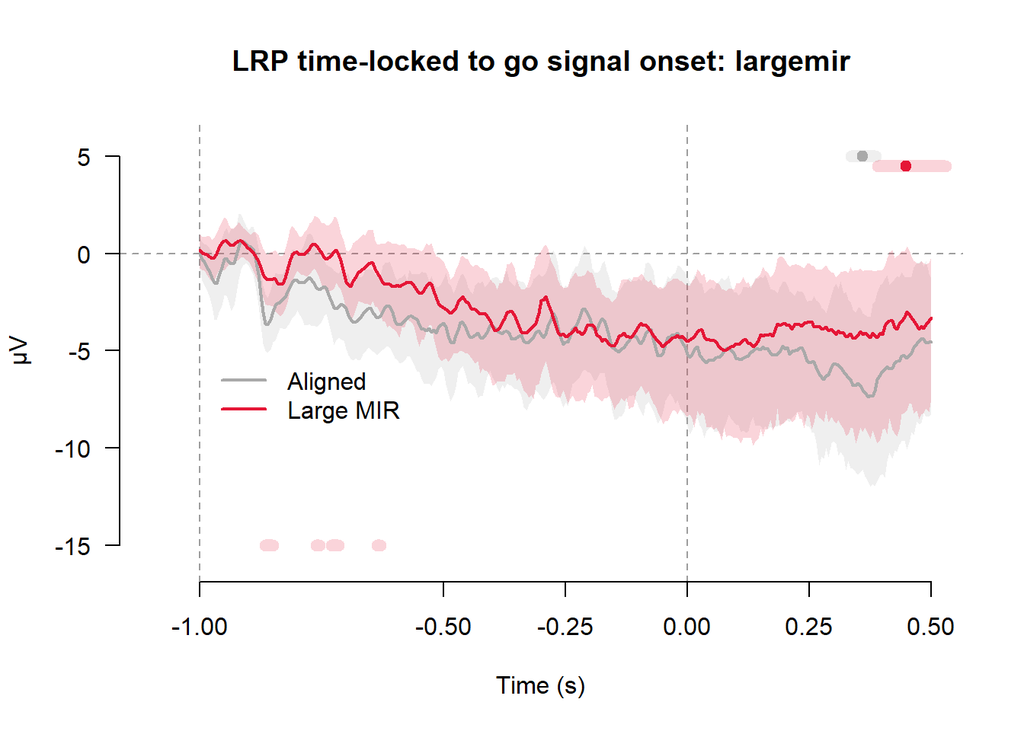

```r
plotPermTestSmallLargeLRPs()
```

#### Comparison between early and late training

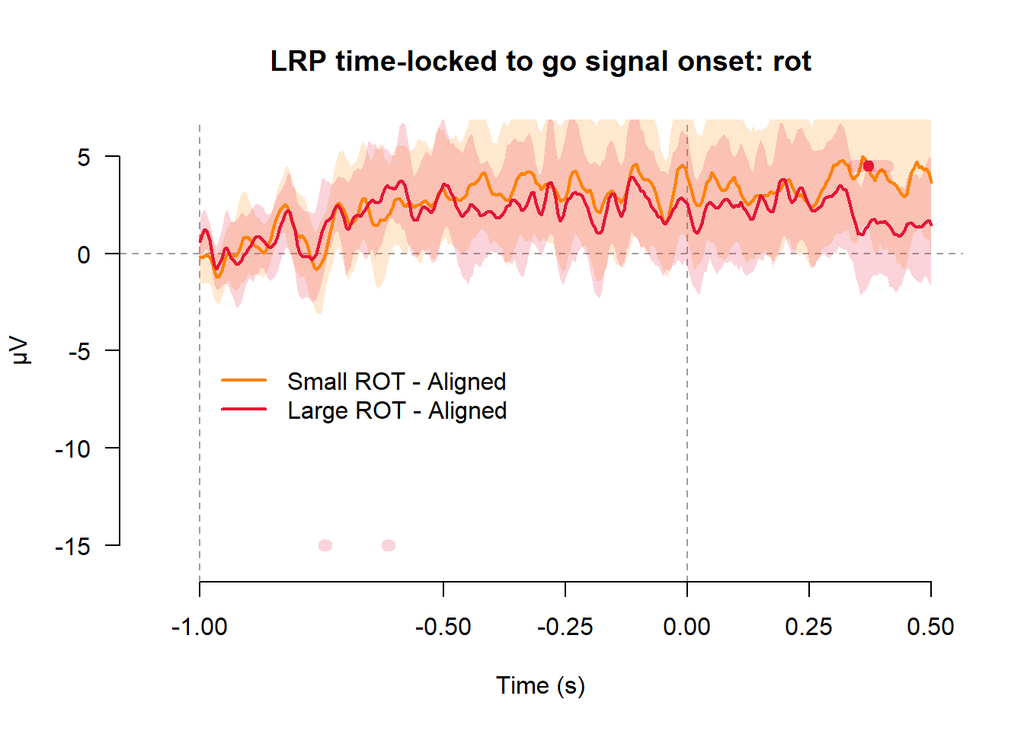

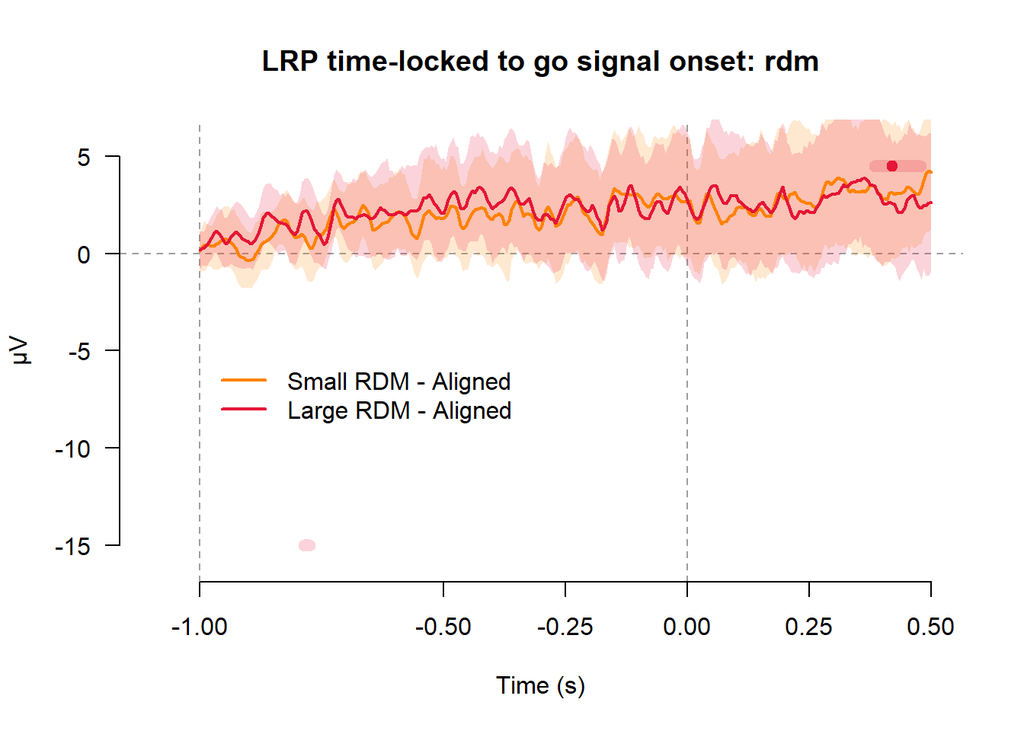

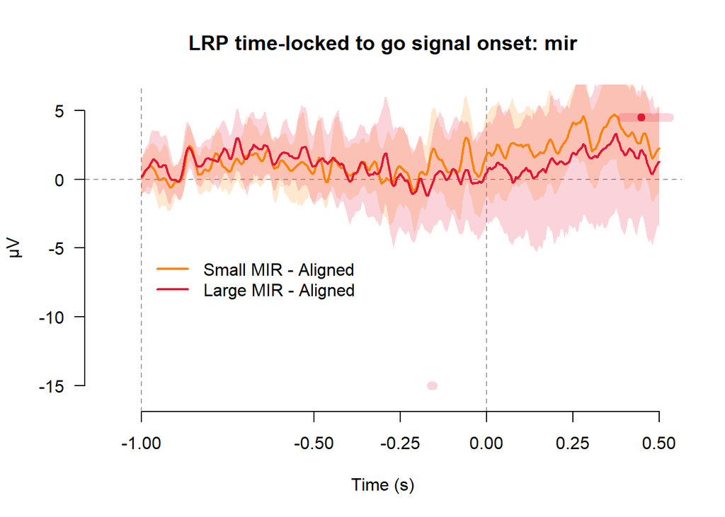

```r
plotPermTestSmallLargeLRPDiffWaves()
```

#### Comparison across perturbation types

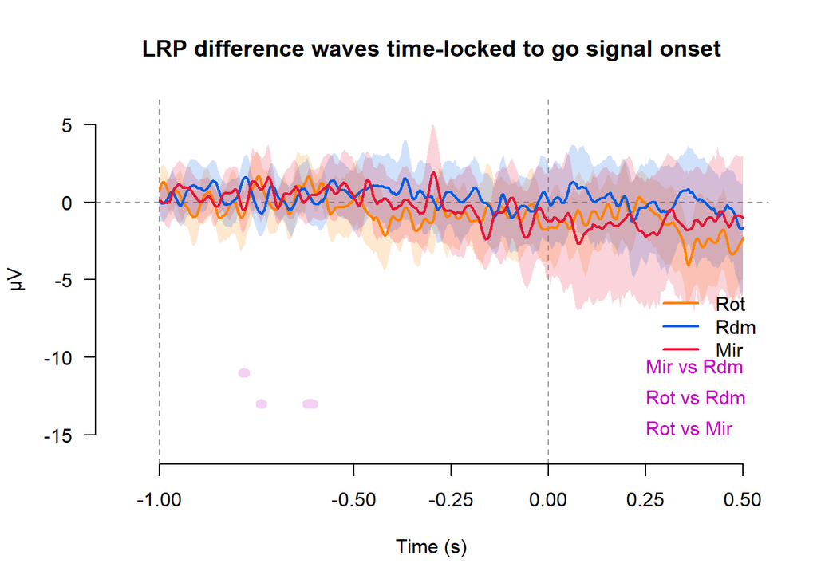

```r
plotPermTestPTypeSmallLargeLRPDiffWaves()
```